# Fresno RIPA Data Project

Stop Duration Outlier Analysis

Catalyst California in Partnership with Fresno BHC

24 September, 2024

Part of the analysis of RIPA data from the Fresno Police Department for this project is to examine how long Fresno PD officers are spending on different types of police stops. This requires a separate stop duration outlier analysis in order to control for stop duration times that are clear outliers in the data. These outliers can be due to data entry error or an officer forgetting to input a stop time and allowing the timer to run on after the stop has concluded.

The goal of this outlier analysis is to identify which stops have stop duration times that are outliers, and then cap those stop duration times appropriately. We do this using a regression model that controls for various factors that influence a stop duration time.

# Load Data and Create Stop-level Data Set

# Creating Dummy Version of Stop-level Data

```r
#### Create dummy version of stop table and gender columns  ####

# Categorical variables need to become separate 1/0 dummy columns for the model

stops_d<-stops%>%
  dummy_cols(select_columns = c("stop_nh_race","stop_reason_simple", "stop_result_simple"))

# clean up the column names remaining

names(stops_d)<- tolower(names(stops_d)) # make all colnames lowercase
colnames(stops_d) = gsub(" ", "_", colnames(stops_d)) # remove all spaces and make underscore
colnames(stops_d) = gsub("-", "", colnames(stops_d)) # remove hyphens

# check no NAs still

# sum(is.na(stops_d)) #0

# pull list of new cols

vars_d<-as.data.frame(colnames(stops_d))

# extract dummy columns we are not keeping: these are the reference groups within each larger category (division, race, stop reason, stop result)

vars_remove<-grep("stop_nh_race_nh_white|stop_reason_simple_traffic_violation|stop_result_simple_citation|g_male",  colnames(stops_d))


# then remove the selected dummy variables we are not keeping
stops_d<-stops_d[,-vars_remove]

# update list of variables in stops_d

vars_d<-as.data.frame(colnames(stops_d))

# rename extra long columns

stops_d<-stops_d%>%


  ### stop reason cols

  rename("stop_reason_simple_consent_search"="stop_reason_simple_consensual_encounter_resulting_in_search")%>%
    rename("stop_reason_simple_truant"="stop_reason_simple_investigation_to_determine_whether_person_was_truant")%>%
    rename("stop_reason_simple_warrant"="stop_reason_simple_knowledge_of_outstanding_arrest/wanted_person")%>%
      rename("stop_reason_simple_parole"="stop_reason_simple_parole/probation/prcs/_mandatory_supervision")%>%
        rename("stop_reason_simple_reasonable_suspicion"="stop_reason_simple_reasonable_suspicion")%>%
          rename("stop_reason_simple_twoormore"="stop_reason_simple_two_or_more_reasons")%>%

  ### stop result cols

    # rename("stop_result_simple_citation"="stop_result_simple_citation_for_infraction")%>%
   rename("stop_result_simple_guardian"="stop_result_simple_contacted_parent/legal_guardian_or_other_person_responsible_for_minor")%>%
    rename("stop_result_simple_arrest_warrant"="stop_result_simple_custodial_arrest_pursuant_to_outstanding_warrant")%>%
      rename("stop_result_simple_arrest_nowarrant"="stop_result_simple_custodial_arrest_without_warrant")%>%
      rename("stop_result_simple_fieldinterviewcard"="stop_result_simple_field_interview_card_completed")%>%
      rename("stop_result_simple_citerelease"="stop_result_simple_in_field_cite_and_release")%>%
    rename("stop_result_simple_transport"="stop_result_simple_noncriminal_transport_or_caretaking_transport")%>%
      rename("stop_result_simple_psychiatric"="stop_result_simple_psychiatric_hold")%>%
  rename("stop_result_simple_schooladmin"="stop_result_simple_referral_to_school_administrator")%>%
      rename("stop_result_simple_twoormore"="stop_result_simple_two_or_more_results")%>%
    rename("stop_result_simple_warning"="stop_result_simple_warning_verbal_or_written")

# make sure no trailing or empty spaces in colnames

names(stops_d) <- gsub(" ", "", names(stops_d))

# update list of variables in dummy df

vars_d<-as.data.frame(colnames(stops_d))
```

# Create and Run Model

Below is a list of the variables we used in this model.

| Variable | Type of variable |
| --- | --- |
| Stop duration | Dependent variable |
| Stop in response to call for service | Independent variable |
| Age of person stopped | Independent variable (continuous) |
| Race of person stopped | Independent variable (categorical) |
| Gender of person stopped | Independent variable (categorical) |
| Stop reason | Independent variable (categorical) |
| Stop result | Independent variable (categorical) |
| Number of people stopped | Independent variable (continuous) |
| Action taken during stop | Independent variable (categorical) |
| Person removed from vehicle | Independent variable (categorical) |
| Contraband found | Independent variable (categorical) |
| Person detained | Independent variable (categorical) |
| Use of force | Independent variable (categorical) |
| Person handcuffed | Independent variable (categorical) |
| Search took place | Independent variable (categorical) |
| Sobriety test conducted | Independent variable (categorical) |

The following are the categorical variables that are not already dummy variables (1/0) and require establishing a reference group.

| Categorical Variable | Reference group |
| --- | --- |
| Stop reason | Traffic violation |
| Stop result | Citation for infraction |
| Race of person stopped | NH White |
| Gender of person stopped | Cis-gender Male |

```r
model<-lm(log(stop_duration) ~

call_for_service+
  persons_count+
   # actions_count+

action_taken+
  handcuffed+
removed_from_vehicle+
detained+
use_of_force+
    ads_prop_seize+
  contraband_found+
   search+
  # contraband_count+
  ads_sobriety_test+
  # ads_firearm_point+
  # ads_removed_vehicle_order+

  age_avg+

g_female+
    g_transgender_man+
     g_transgender_woman+
     # g_multigender+ # Removing this from the model because this variable is aliased when running vif score probably due to addition of g_multiple column from gender recoding - which encompasses all stops of g_multigender
    g_gender_nonconforming+
  g_multiple+

stop_nh_race_latinx +
stop_nh_race_nh_aian+
stop_nh_race_nh_asian+
stop_nh_race_nh_black+
stop_nh_race_nh_multi_race+
  stop_nh_race_nh_multiracial+
stop_nh_race_nh_nhpi+
 stop_nh_race_nh_sswana+



stop_reason_simple_consent_search+
stop_reason_simple_truant+
stop_reason_simple_warrant+
stop_reason_simple_parole+
  stop_reason_simple_reasonable_suspicion+
stop_reason_simple_twoormore+

  # stop_result_simple_citation+ # reference group
stop_result_simple_no_action+
stop_result_simple_guardian+
stop_result_simple_arrest_warrant+
stop_result_simple_arrest_nowarrant+
stop_result_simple_fieldinterviewcard+
stop_result_simple_citerelease+
stop_result_simple_transport+
stop_result_simple_psychiatric+
stop_result_simple_schooladmin+
stop_result_simple_twoormore+
  stop_result_simple_warning,

            data = stops_d)
```

## VIF Values

Test for multicollinearity among independent variables: calculate Variance Influence Factor (VIF) scores of independent variables in model + As a rule of thumb, a VIF value that exceeds 5 or 10 indicates a problematic amount of collinearity (James et al. 2014). We retain any categorical variables that have slightly higher VIF score to ensure our reference categories remain the same (e.g., stops made for reasonable suspicion).

```r
# Test for multicolinearity: Visualize variance influence factors (VIF)

vif_values <- vif(model)

vif_values
```

```
FALSE                        call_for_service                           persons_count
FALSE                                4.061504                                2.336096
FALSE                            action_taken                              handcuffed
FALSE                                3.350266                                3.182194
FALSE                    removed_from_vehicle                                detained
FALSE                                1.733390                                2.133529
FALSE                            use_of_force                          ads_prop_seize
FALSE                                1.263719                                1.684974
FALSE                        contraband_found                                  search
FALSE                                2.050006                                2.395747
FALSE                       ads_sobriety_test                                 age_avg
FALSE                                1.109817                                1.033610
FALSE                                g_female                       g_transgender_man
FALSE                                1.048055                                1.131782
FALSE                     g_transgender_woman                  g_gender_nonconforming
FALSE                                1.011600                                1.001028
FALSE                              g_multiple                     stop_nh_race_latinx
FALSE                                1.807253                                1.504860
FALSE                    stop_nh_race_nh_aian                   stop_nh_race_nh_asian
FALSE                                1.021107                                1.120919
FALSE                   stop_nh_race_nh_black              stop_nh_race_nh_multi_race
FALSE                                1.302382                                1.541094
FALSE             stop_nh_race_nh_multiracial                    stop_nh_race_nh_nhpi
FALSE                                1.018371                                1.001659
FALSE                  stop_nh_race_nh_sswana       stop_reason_simple_consent_search
FALSE                                1.215050                                1.471636
FALSE               stop_reason_simple_truant              stop_reason_simple_warrant
FALSE                                1.562791                                1.424417
FALSE               stop_reason_simple_parole stop_reason_simple_reasonable_suspicion
FALSE                                1.087635                                5.155970
FALSE            stop_reason_simple_twoormore            stop_result_simple_no_action
FALSE                                1.200049                                1.166618
FALSE             stop_result_simple_guardian       stop_result_simple_arrest_warrant
FALSE                                1.399530                                1.707965
FALSE     stop_result_simple_arrest_nowarrant   stop_result_simple_fieldinterviewcard
FALSE                                2.332095                                1.086212
FALSE          stop_result_simple_citerelease            stop_result_simple_transport
FALSE                                1.065731                                1.183689
FALSE          stop_result_simple_psychiatric          stop_result_simple_schooladmin
FALSE                                1.313092                                1.020965
FALSE            stop_result_simple_twoormore              stop_result_simple_warning
FALSE                                1.425827                                1.064172
```

```r
# Variable tested and removed later due to high VIF or for better conceptual fit
# actions_count--captured in action_taken,
# ads_removed_vehicle_order--captured in removed_from_vehicle
# stop_result_simple_citation--made reference because it's a larger category and added stop_result_simple_no_action
# ads_firearm_point--captured in use of force
# contraband_count--captured in contraband found

# while  stop_reason_simple_reasonable_suspicion has a slightly high VIF score, we keep it in the model to ensure the reference category for stop reason stays as traffic violation only
```

## Regression Summary

The regression summary table shows us the p values for all our independent variables. Note some have high p values (>.10) and are therefore not statistically significant at a 90% confidence interval. This could be because these variables have a small n, or these variables do not occur often.

The current model has a R^2 of 59% which is a good indication that our model is robust. This means that 59% of variance in stop duration times is explained by our model.

The diagnostic plots give us a sense of how robust our working model is and if any adjustments are needed. See this reference link for understanding diagnostic plots and what we want them to look like in order to feel confident about our model.

```r
#summarize result

summ(model)
```

| Observations | 5317 |
| --- | --- |
| Dependent variable | log(stop_duration) |
| Type | OLS linear regression |

| F(42,5274) | 180.93 |
| --- | --- |
| R² | 0.59 |
| Adj. R² | 0.59 |

|  | Est. | S.E. | t val. | p |
| --- | --- | --- | --- | --- |
| (Intercept) | 1.86 | 0.08 | 23.05 | 0.00 |
| call_for_service | 0.29 | 0.05 | 5.79 | 0.00 |
| persons_count | 0.11 | 0.08 | 1.43 | 0.15 |
| action_taken | 0.81 | 0.03 | 25.01 | 0.00 |
| handcuffed | 0.25 | 0.05 | 4.93 | 0.00 |
| removed_from_vehicle | 0.32 | 0.04 | 7.95 | 0.00 |
| detained | -0.05 | 0.04 | -1.35 | 0.18 |
| use_of_force | -0.25 | 0.07 | -3.42 | 0.00 |
| ads_prop_seize | -0.26 | 0.08 | -3.18 | 0.00 |
| contraband_found | 0.24 | 0.06 | 4.22 | 0.00 |
| search | -0.00 | 0.04 | -0.01 | 0.99 |
| ads_sobriety_test | 0.78 | 0.08 | 10.14 | 0.00 |
| age_avg | -0.00 | 0.00 | -3.47 | 0.00 |
| g_female | -0.02 | 0.01 | -1.31 | 0.19 |
| g_transgender_man | -0.28 | 0.22 | -1.29 | 0.20 |
| g_transgender_woman | -0.48 | 0.41 | -1.17 | 0.24 |
| g_gender_nonconforming | 0.36 | 0.29 | 1.25 | 0.21 |
| g_multiple | 0.30 | 0.12 | 2.52 | 0.01 |
| stop_nh_race_latinx | 0.02 | 0.01 | 1.16 | 0.25 |
| stop_nh_race_nh_aian | 0.39 | 0.16 | 2.47 | 0.01 |
| stop_nh_race_nh_asian | 0.03 | 0.03 | 1.12 | 0.26 |
| stop_nh_race_nh_black | 0.05 | 0.02 | 2.48 | 0.01 |
| stop_nh_race_nh_multi_race | -0.16 | 0.19 | -0.85 | 0.40 |
| stop_nh_race_nh_multiracial | 0.59 | 0.19 | 3.18 | 0.00 |
| stop_nh_race_nh_nhpi | -0.12 | 0.29 | -0.42 | 0.67 |
| stop_nh_race_nh_sswana | 0.07 | 0.02 | 2.88 | 0.00 |
| stop_reason_simple_consent_search | -0.03 | 0.18 | -0.19 | 0.85 |
| stop_reason_simple_truant | 0.29 | 0.26 | 1.14 | 0.25 |
| stop_reason_simple_warrant | -0.32 | 0.10 | -3.03 | 0.00 |
| stop_reason_simple_parole | -0.91 | 0.19 | -4.76 | 0.00 |
| stop_reason_simple_reasonable_suspicion | 0.23 | 0.06 | 3.66 | 0.00 |
| stop_reason_simple_twoormore | -0.94 | 0.45 | -2.08 | 0.04 |
| stop_result_simple_no_action | -0.16 | 0.06 | -2.72 | 0.01 |
| stop_result_simple_guardian | -0.17 | 0.49 | -0.35 | 0.73 |
| stop_result_simple_arrest_warrant | 0.41 | 0.07 | 5.80 | 0.00 |
| stop_result_simple_arrest_nowarrant | 0.47 | 0.06 | 8.03 | 0.00 |
| stop_result_simple_fieldinterviewcard | -0.41 | 0.17 | -2.37 | 0.02 |
| stop_result_simple_citerelease | 0.33 | 0.02 | 16.77 | 0.00 |
| stop_result_simple_transport | 0.22 | 0.45 | 0.50 | 0.62 |
| stop_result_simple_psychiatric | 0.72 | 0.14 | 5.06 | 0.00 |
| stop_result_simple_schooladmin | -0.12 | 0.42 | -0.29 | 0.78 |
| stop_result_simple_twoormore | 0.33 | 0.04 | 7.37 | 0.00 |
| stop_result_simple_warning | -0.06 | 0.02 | -2.79 | 0.01 |

Standard errors: OLS

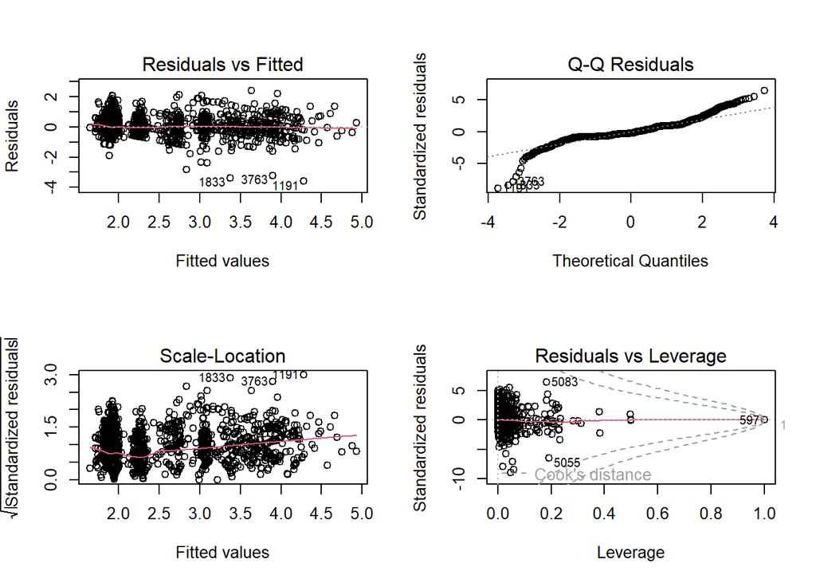

```r
# plot diagnostics
par(mfrow=c(2,2))
plot(model)
```

# Identifying Outliers

We use these guiding rules to determine which stop duration times are outliers from our model:

Key reference material: Belsley, D.A.; Kuh, E., Welsh, R. E. (1980). Regression Diagnostics: Identifying Influential Data and Sources of Collinearity. Rules of Thumb” used to identify potential outliers: (k=number of IVs; N= Sample size) NOTE: These ‘rules’ are not a hard-and-fast rule, but rather a guideline only! ALWAYS produce a plot/histogram or sample quantiles of your outlier measures

Measure Cut-off Value:

- abs(standardized resid) > 2 (or 3)
- leverage >(2k,2)/N
- abs(Dffits) > 2/sqrt(k,1/N)
- abs(Dfbetas) > 2/sqrt(N)
- Cook’s D > 4/N

Source: http://rstudio-pubs-static.s3.amazonaws.com/477250_8b19e334ad1245c9b9259e9c5db36089.html#7_identifying_outliers

```r
# reference: http://rstudio-pubs-static.s3.amazonaws.com/477250_8b19e334ad1245c9b9259e9c5db36089.html#7_identifying_outliers

# calculate each unit of measure for outlier threshold analysis

model_all_metrics <- augment(model)
```

# Identifying and Capping Outliers Using Predictive Interval

We cap stop times that are either below or above their predictive interval based on their stop characteristics. In total, 180 stops have an upper cap applied and 84 have a lower cap applied. Together they represent only 5.0% of stops in 2022.

- Resource, CI vs Predicted Interval: https://towardsdatascience.com/confidence-intervals-vs-prediction-intervals-7b296ae58745
- Resource: https://rpubs.com/aaronsc32/regression-confidence-prediction-intervals

```r
#### Calculate Predicted Value (pv) and Predicted Value Confidence Intervals####

 # Create a dataframe that has a identifier value column we will use to add in the predicted values

pv<-stops%>%
  select(stop_id)

# Then calculate the predicted value of stop_duration. Because this is a logarithmic model, the predicted values are logs

pv[c("pv_log", "lwr_log", "upr_log")]<-predict(model, newdata=stops_d, interval="prediction")

# Add a new column taking the inverse of the logarithmic predicted value and confidence intervals to revert stop_time and CI predicted values to non-log form

pv<-pv%>%mutate(pv=exp(pv_log),
                          lwr=exp(lwr_log),
                          upr=exp(upr_log))

# join the pv table to stops table

stops<-stops%>%
  left_join(pv, by = c("stop_id" = "stop_id"))

# select columns of interest

final_cap<-stops%>%
select(c("stop_id", "stop_duration", "pv", "lwr", "upr", "pv_log", "upr_log", "lwr_log"))

#### Determine outlier based off lwr and upr prediction value intervals ####

# create column indicating if that row requires a upper or lower cap, then implement cap

final_cap<-final_cap%>%
 mutate(cap_type=ifelse(stop_duration>upr, "high",
                         ifelse(stop_duration<lwr, "low", "none")))%>%
  mutate(stop_duration_capped=ifelse(cap_type=="high", upr,
                              ifelse(cap_type=="low", lwr,
                                     stop_duration)))

# rearrange column order

col_order <- c("stop_id", "stop_duration", "stop_duration_capped", "cap_type",  "pv", "lwr","upr", "pv_log", "lwr_log", "upr_log")

final_cap <- final_cap[, col_order]

#### Explore results: ####

# table(final_cap$cap_type)

# sum(is.na(final_cap$stop_duration_capped)) # 0 NAs

high<-final_cap%>%
  filter(cap_type=='high')

low<-final_cap%>%
  filter(cap_type=='low')
```

# Descriptive Stats Testing

Take the stop duration capped values created using the Predicted Value Confidence Interval method and run some descriptive stats.

## Original Stop Times: Officer-initiated Stop Counts and Time Stats for Fresno PD

```r
# prep data

df <- stops %>%
  select(stop_id, call_for_service, stop_duration) %>%
  mutate(Total = sum(stop_duration, na.rm = TRUE)) %>%
  group_by(call_for_service) %>%
  mutate(Count = sum(stop_duration, na.rm = TRUE),
         'Percent Mins' = Count/Total*100,
         'Average Stop Time (Mins)' = mean(stop_duration, na.rm = FALSE),
         'Median Stop Time (Mins)' = median(stop_duration, na.rm = FALSE),
         'Min Stop Time (Mins)' = min(stop_duration, na.rm = FALSE),
         'Max Stop Time (Mins)' = max(stop_duration, na.rm = FALSE),
         'Total Time (Mins)' = Total,
         'Count Mins' = Count
  ) %>%
  slice(1) %>%
  select(-c(stop_id, stop_duration, Count, Total)) %>%
  mutate(call_for_service = ifelse(call_for_service %in% 0, 'No', 'Yes')) %>%
  rename('Call for Service' = 'call_for_service') %>%
  relocate('Count Mins', .after = 'Call for Service')

# Create and style flextable
df %>%
  flextable() %>%
  colformat_double(j = c("Count Mins", "Percent Mins", "Average Stop Time (Mins)", 'Median Stop Time (Mins)',
                         'Min Stop Time (Mins)', 'Max Stop Time (Mins)', 'Total Time (Mins)'), digits = 1) %>%
  set_caption('Original Times: Stop Time by Response to Service Call for Fresno PD (2022)') %>%
  theme_vanilla()
```

Original Times: Stop Time by Response to Service Call for Fresno PD (2022)

| Call for Service | Count Mins | Percent Mins | Average Stop Time (Mins) | Median Stop Time (Mins) | Min Stop Time (Mins) | Max Stop Time (Mins) | Total Time (Mins) |
| --- | --- | --- | --- | --- | --- | --- | --- |
| No | 46,073.0 | 74.1 | 9.2 | 7.0 | 1.0 | 180.0 | 62,192.0 |
| Yes | 16,119.0 | 25.9 | 55.8 | 30.0 | 1.0 | 480.0 | 62,192.0 |

## With Capped Stop Times: Officer-initiated Stop Counts and Time Stats

```r
df<-stops%>%
  select(stop_id, call_for_service, stop_duration)%>%
  left_join(final_cap)%>%
  mutate(Total=sum(stop_duration_capped,na.rm=TRUE))%>%
  group_by(call_for_service)%>%
  mutate(Count=sum(stop_duration_capped,na.rm=TRUE),
         'Percent Mins'=Count/Total*100,
         'Average Stop Time (Mins)' = mean(stop_duration_capped, na.rm = FALSE),
            'Median Stop Time (Mins)'=   median(stop_duration_capped,na.rm = FALSE),
             'Min Stop Time (Mins)'=min(stop_duration_capped,na.rm = FALSE),
            'Max Stop Time (Mins)'=max(stop_duration_capped,na.rm = FALSE),
             'Total Time (Mins)'= Total,
         'Count Mins'=Count
         )%>%
  slice(1)%>%
  select(2, 14:20)%>%
  mutate(call_for_service=ifelse(call_for_service %in% 0, 'No', 'Yes'))%>%
    rename('Call for Service'='call_for_service')%>%
     relocate('Count Mins', .after = 'Call for Service')


#create and style flextable

  flextable(df) %>%
colformat_double(j = c("Count Mins", "Percent Mins", "Average Stop Time (Mins)",'Median Stop Time (Mins)',
                       'Min Stop Time (Mins)','Max Stop Time (Mins)', 'Total Time (Mins)'), digits = 1)%>%
  set_caption('Capped Times: Stop Time by Response to Service Call, Fresno PD (2022)') %>%
  theme_vanilla()
```

Capped Times: Stop Time by Response to Service Call, Fresno PD (2022)

| Call for Service | Count Mins | Percent Mins | Average Stop Time (Mins) | Median Stop Time (Mins) | Min Stop Time (Mins) | Max Stop Time (Mins) | Total Time (Mins) |
| --- | --- | --- | --- | --- | --- | --- | --- |
| No | 44,476.7 | 76.1 | 8.8 | 7.0 | 2.7 | 132.5 | 58,418.5 |
| Yes | 13,941.8 | 23.9 | 48.2 | 31.8 | 4.0 | 240.7 | 58,418.5 |